# DataMiningReport

# Prediction of Economic Recession with Precision

TEAM: RR MINERS Doondi Tammineedi[1], Jarod Reith[2], Samiksha Aryal[3], Sowmya Velamuri[4], Anirudh Koganti[5], Devashish Nunna[6] Department of Computer Science Missouri University of Science and Technology

# Abstract

Recession prediction is a crucial task in economic forecasting. Traditional econometric models struggle to capture the complex interdependencies among macroeconomic indicators. This study proposes a novel framework integrating graphtheoretic techniques and Graph Neural Networks (GNNs) to predict recessions by modeling economic indicators as nodes and their interdependencies as weighted edges. We then proceed to construct the graph and train GNN models such as Graph Convolutional Networks (GCN) and Temporal Graph Neural Networks (TGNN) to derive meaningful insights. Experimental results demonstrate that this approach provides accurate, interpretable, and early-warning signals for economic downturns.

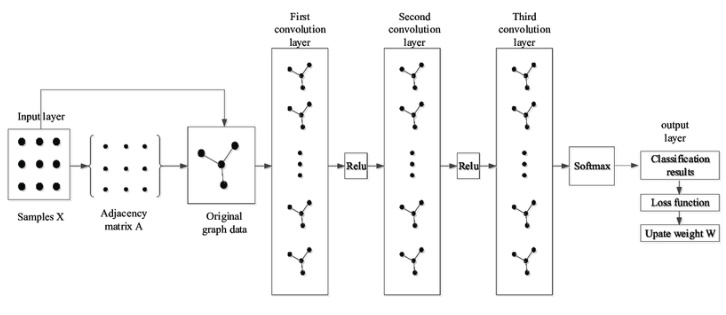

Fig. 1. Illustration of Graph Neural Network Framework

## I. INTRODUCTION

### A. Motivation

Recession forecasting is an important aspect for policymakers, financial institutions, and businesses. Accurate predictions can help governments design timely fiscal and monetary interventions, businesses adjust investment strategies, and financial institutions manage risks effectively. Existing econometric models, such as Probit, Logit, XGboost, LSTM and other time-series methods, have long been used for recession forecasting. These models, while effective in certain contexts, are inherently limited by their reliance on linear assumptions and their inability to capture the complex, nonlinear relationships that often exist among macroeconomic variables. For instance, traditional econometric models tend to treat each indicator—such as GDP, unemployment rate, inflation, and interest rates—independently or through simple pairwise correlations, failing to consider the multidimensional interdependencies among them.

Macroeconomic indicators, however, do not operate in isolation. They are interconnected and influence each other dynamically, creating a complex web of relationships that evolve over time. Understanding and predicting recession events requires an approach that can capture these intricate interactions and their temporal evolution.

### B. Problem Statement

Existing econometric and machine learning models fall short in capturing the intricate and dynamic dependencies that exist among macroeconomic indicators. This study addresses this limitation by introducing a graph-based recession prediction framework, where economic indicators are represented in a structured dynamic network with their interdependencies as weighted edges and leveraging Graph Theoretic measures, GNNs to learn the underlying predictive patterns.

### C. Objectives

To construct a dynamic graph-based representation of the U.S. economy from real-world financial time series data and to identify and interprete structural disruptions in the economic system.  
Employ Graph Neural Networks (GNNs) to model complex dependencies: To capture the relationships between economic indicators, allowing for more accurate recession predictions.  
To evaluate and compare the performance of the proposed method against traditional econometric models: Assess the effectiveness of the graph-based approach in predicting recessions by comparing its performance to traditional forecasting models.

### D. Contributions

A unified graph-theoretic and deep learning framework for recession prediction  
Integration of structural graph network into economic modeling  
Development of a custom graph dataset from real-world economic indicators  
• Comparative evaluation against traditional and deep learning models

## II. RELATED WORK

Several studies have explored recession forecasting using statistical and machine learning techniques. Traditional models like Probit and Logit, More recent machine learning methods, such as LASSO regression, ($\mathbf { k }$) -Nearest Neighbors (k-NN), and Bayesian models, have improved forecasting accuracy but lack interpretability in capturing interdependencies between economic variables and often miss structural economic shifts. while LSTMs handle time dependencies well, they still treat each feature independently, lacking the capability to model inter-indicator structural relationships. Graph-based models capture dynamic interactions and offer new insights into regime changes.

TABLE I SUMMARY OF RELATED LITERATURE AND GAPS IDENTIFIED

[output not shown]

## III. PROPOSED METHODOLOGY

To effectively forecast economic recessions, our approach combines graph formulation with deep learning. We first construct dynamic economic networks from macroeconomic indicators, then extract meaningful structural features using established Graph Neural Networks. The constructed graph from the data features is sent as input to Graph Neural Networks (GNNs), which are trained to detect recessionary patterns. The methodology comprises stages, described below.

### A. Data Collection

We use the Financial Indicators of US Recession dataset from Kaggle, which includes 27 economic indicators in individual datasets. These were combined with monthly recession labels sourced from the National Bureau of Economic Research (NBER) to form a custom dataset of 22 Classes (from 1985 to 2023). The 22 classes include : 10-Year Real Interest Rate, Bank Credit (All Commercial Banks), Consumer Price Index for All Urban Consumers All Items in U.S. City Average, Consumer Price Index Total All Items for the United States, Continued Claims (Insured Unemployment), Federal Funds Effective Rate,Gross Domestic Product, Households Owners Equity in Real Estate Level Inflation consumer prices for the United States, M1, M2, Median Consumer Price Index, Personal Saving Rate, Real Estate Loans Commercial Real Estate Loans All Commercial Banks, Real Estate Loans Residential Real Estate Loans Revolving Home Equity Loans All Commercial Banks, Real Gross Domestic Product, Sticky Price Consumer Price Index less Food and Energy, Sticky Price

Consumer Price Index, Unemployment Level, Unemployment Rate, recession (label from NBER)

### B. Data Pre Processing

Handling Missing Data: Any missing or incomplete values are imputed using interpolation methods (e.g., linear interpolation, forward filling), or if large portions of data are missing ($( > 1 0 \% )$) , those time periods are excluded from the analysis.  
Normalization/Standardization: Each feature is scaled to ensure equal contribution to the model using z-score normalization:

$$\mathbf { x } _ { i } ^ { \mathrm { { n o r m } } } = \frac { \mathbf {
x } _ { i } - \mu _ { i } } { \sigma _ { i } }$$

where ($\mu _ { i }$) and ($\sigma _ { i }$) are the mean and standard deviation of

feature ($i$) , respectively.  
• Data Type Enforcement: All features are explicitly cast to numeric types. Non-convertible rows are removed to prevent downstream errors during modeling.  
• Class Imbalance Handling via SMOTE: To address the imbalance in recession versus non-recession samples, SMOTE (Synthetic Minority Oversampling Technique) is used to oversample the minority class (recession class), enabling more balanced training.  
Stratified Splitting: The dataset is split into training and testing sets using a stratified approach to preserve the distribution of recession labels across both sets.  
Temporal Alignment: Macroeconomic indicators with differing time granularities are temporally aligned (daily/monthly/quarterly) to ensure synchronized input for modeling.

### C. Graph Construction

After preprocessing the data, we construct a graph as shown in Fig. 2 The graph ($G = ( V , E )$) is defined as follows:

• ($V = \{ v _ { 1 } , v _ { 2 } , \ldots , v _ { n } \}$) is the set of nodes, where each node corresponds to a macroeconomic indicator (e.g., GDP, unemployment rate, inflation). • ($E = \{ e _ { 1 } , e _ { 2 } , \dots , e _ { m } \}$) is the set of edges representing relationships between indicators. The strength of each edge is computed using the Pearson correlation coefficient.

The Pearson correlation coefficient ($r _ { i j }$) between two indicators ($i$) and ($j$) over a given time window is defined as:

$$r _ { i j } = \frac { \sum _ { t = 1 } ^ { n } ( x _ { i } ( t ) - \bar
{ x } _ { i } ) ( x _ { j } ( t ) - \bar { x } _ { j } ) } { \sqrt {
\sum _ { t = 1 } ^ { n } ( x _ { i } ( t ) - \bar { x } _ { i } ) ^ { 2
} } \sqrt { \sum _ { t = 1 } ^ { n } ( x _ { j } ( t ) - \bar { x } _ {
j } ) ^ { 2 } } }$$

where:

($x _ { i } ( t )$) and ($x _ { j } ( t )$) are the values of indicators ($i$) and ($j$) at time ($t$) , ($\bar { x } _ { i }$) and ($\bar { x } _ { j }$) are the means of the respective time series.

Each edge weight ($w _ { i j }$) in the adjacency matrix ($A$) is assigned as ($w _ { i j } ~ = ~ r _ { i j }$) , representing the linear dependency between the indicators. The resulting graph is constructed from the Adjacency matrix using the networkx library, forming a weighted undirected graph for each time snapshot.

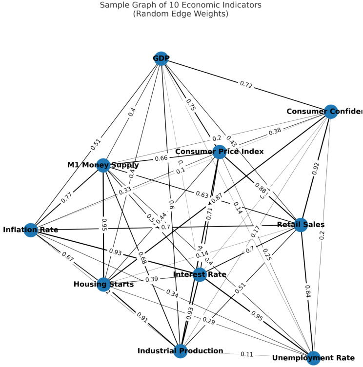

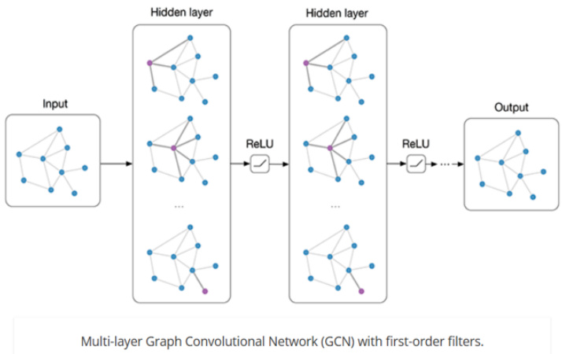

Fig. 3. Graph Convolution Network Framework

## IV. GRAPH NEURAL NETWORKS FOR PREDICTION

We construct such graphs (as shown in Fig. 2 ) for every timestamp, after constructing the graph, we apply Graph Neural Networks (GNNs) to model the dependencies between the macroeconomic indicators to understand underlying dependencies and predict recessions.

### A. Graph Convolutional Network (GCN)

Graph Convolutional Networks (GCNs) as seen in Fig. 3, are neural networks that operate directly on graph structures. Each node updates its representation by aggregating and transforming feature information from its neighbors using the graph’s adjacency matrix. This enables the model to capture local structure and feature dependencies. By stacking multiple

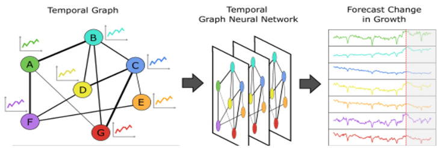

Fig. 4. Temporal Graph Neural Network Framework

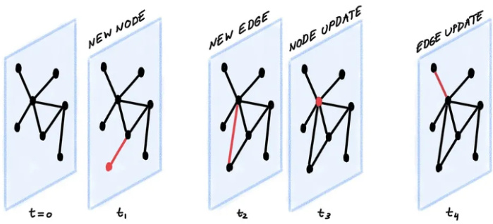

Fig. 5. Dynamic Sequence of Graph Snanpshots

GCN layers,allows information to propagate through the graph (as in TGNN), this enables each node to incorporate information from increasingly distant nodes, enabling the model to capture long-range dependencies in the graph and learn from multi-hop neighborhoods.

The input to the GCN consists of a single static graph constructed from macroeconomic indicators. The node features are derived from normalized values of these indicators at a specific time point or averaged over a fixed time window. This graph, along with its node features, is used to predict the presence or absence of a recession during the corresponding time window.The layer-wise update rule for node ($i$) is given by:

$$\mathbf { h } _ { i } ^ { ( t + 1 ) } = \sigma \left( \sum _ { j \in
\mathcal { N } ( i ) } \frac { A _ { i j } } { \sqrt { d _ { i } d _ { j
} } } \mathbf { h } _ { j } ^ { ( t ) } \right)$$

where:

• ($\mathbf { h } _ { i } ^ { ( t ) }$) is the feature vector of node ($i$) at layer ($t$) , ($A _ { i j }$) is the entry in the adjacency matrix representing the edge between nodes ($\mathbf { \chi } _ { i }$) and ($j$) , • ($d _ { i }$) and ($d _ { j }$) are the degrees of nodes ($i$) and ($j$) , ($\sigma$) is a non-linear activation function, such as ReLU.

### B. Temporal GNN (TGNN)

TGNN (as seen in Fig. 4 ) extend traditional GNNs by incorporating temporal dynamics, allowing node representations to evolve over time. They account for both spatial (graph) and temporal dependencies by updating node features based on prior time steps and their neighbors. In the context of recession prediction, TGNNs process a dynamic sequence of graph snapshots (Fig. 5). Each snapshot has the same set of nodes (economic indicators), but the node features and edge weights change over time to reflect current indicator values and their relationships (e.g., time-specific Pearson correlations).

The input to the TGNN is a sequence of such dynamic graphs, the node features are composed of the normalized values of the indicators at each respective time step. The TGNN uses this input to model how node representations change over time and and learn how the network evolves and predict recession labels based on trends observed across time. The feature update rule for node ($i$) at time ($t$) is given by:

$$\mathbf { h } _ { i } ( t ) = \sigma \left( \sum _ { j \in \mathcal { N
} ( i ) } A _ { i j } \cdot \mathbf { h } _ { j } ( t - 1 ) + \mathbf {
W } \cdot \mathbf { x } _ { i } ( t ) \right)$$

where:

- (${ \bf h } _ { i } ( t )$) is the feature vector of node ($i$) at time ($t$) ,
- (${ \bf h } _ { j } ( t - 1 )$) is the feature vector of neighboring node ($j$) at time ($t - 1$) ,
- (${ \bf x } _ { i } ( t )$) is the input feature of node ($i$) at time ($t$) ,
- ($A _ { i j }$) is the adjacency matrix entry between nodes ($\mathbf { \chi } _ { i }$) and ($j$) , W is a learnable weight matrix,
- ($\sigma$) is a non-linear activation function (e.g., ReLU),
- ($\mathcal { N } ( i )$) denotes the neighbors of node ($i$) .

To stabilize updates and smooth temporal transitions, TGNNs may also apply a temporal smoothing operation:

$$\mathbf { h } _ { i } ( t ) = \alpha \cdot \mathbf { h } _ { i } ( t - 1
) + ( 1 - \alpha ) \cdot \sum _ { j \in \mathcal { N } ( i ) } A _ { i j
} \cdot \mathbf { h } _ { j } ( t - 1 )$$

where ($\alpha ~ \in ~ [ 0 , 1 ]$) is a smoothing hyperparameter that controls the trade-off between a node’s past state and the influence of its neighbors at the previous time step.